# Лабораторная работа №5

Менеджер паролей pass и управление файлами конфигурации

Липатников Андрей

1032253853@rudn.ru

Российский университет дружбы народов

2026-10-08

# Информация

## Докладчик

- Липатников Андрей
- Студент Российского университета дружбы народов им. П. Лумумбы
- 1032253853@rudn.ru

# Вводная часть

## Актуальность

- Работа с виртуальными машинами порождает две практические задачи:
  - безопасное хранение множества паролей и доступ к ним с разных устройств;
  - перенос файлов конфигурации (dotfiles) между машинами.
- Пароли в открытом виде недопустимы, облачные менеджеры требуют доверия к третьей стороне
- Ручное копирование настроек не масштабируется и приводит к расхождению конфигураций
- Весь практикум курса разворачивается и переносится именно этими инструментами

## Объект и предмет исследования

- **Объект**: процессы управления паролями и файлами конфигурации домашнего каталога пользователя
- **Предмет**: настройка менеджера паролей pass с шифрованием GPG и синхронизацией git, а также управление конфигурациями с помощью chezmoi и репозитория dotfiles
- **Критерий результата**: работающее шифрованное хранилище паролей и развёрнутые конфигурации на двух машинах

## Цели и задачи

- Цель:
  - Получить навыки работы с менеджером паролей pass и утилитой управления файлами конфигурации chezmoi.
- Задачи:
  - Установить pass и gopass, настроить хранилище с шифрованием GPG-ключом.
  - Синхронизировать хранилище с git, настроить связь с браузером (browserpass).
  - Установить chezmoi, создать репозиторий dotfiles и развернуть конфигурации на двух машинах.

# Материалы и методы

## Используемое ПО и среда

- **Среда**: Fedora 41 (Sway) в VirtualBox (окружение из лабораторной работы №1)
- **Инструменты**:
  - `pass`, `pass-otp`, `gopass`, `gnupg` — хранилище паролей и шифрование
  - `browserpass` — интеграция с браузером (репозиторий Copr)
  - `chezmoi`, `git`, `gh` — управление файлами конфигурации
- **Репозитории**: личный репозиторий хранилища паролей и dotfiles на GitHub

## Методика выполнения

- Установка и настройка менеджера паролей pass
- Синхронизация хранилища с git-репозиторием
- Настройка взаимодействия с браузером и работа с паролями
- Установка дополнительного ПО и шрифтов рабочего окружения
- Развёртывание конфигураций chezmoi на первой и второй машинах
- Освоение ежедневных операций: diff, apply, update, autoCommit, autoPush

# Содержание исследования

## Установка pass и gopass

- Менеджер паролей pass установлен с модулем otp, реализация gopass — отдельно
- Ключ для шифрования уже существует: генерация нового не потребовалась
- Список секретных ключей проверен командой `gpg --list-secret-keys`

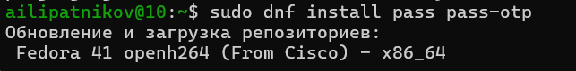

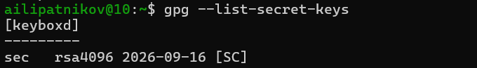

## Синхронизация хранилища с git

- Инициализация структуры git в хранилище: `pass git init`
- Задан адрес репозитория на GitHub, изменения отправлены: `pass git push`
- Прямые изменения файловой системы фиксируются вручную: pass отслеживает только свои операции

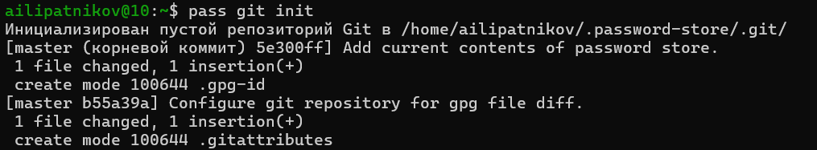

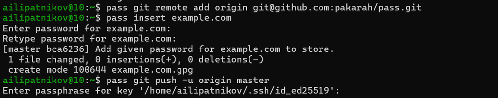

## Взаимодействие с браузером

- Интеграция с браузером — через native messaging: плагин плюс программа-интерфейс
- Включён репозиторий Copr: `dnf copr enable maximbaz/browserpass`
- Установлен пакет browserpass

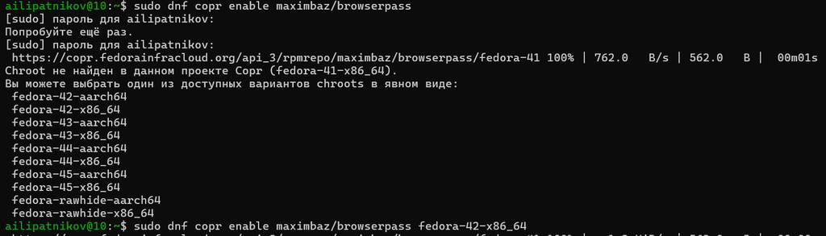

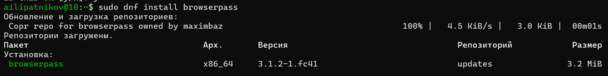

## Работа с паролями

- Добавлен пароль: `pass insert email/rudn.ru`
- Отображён: `pass email/rudn.ru`
- Заменён сгенерированным на месте: `pass generate --in-place email/rudn.ru`

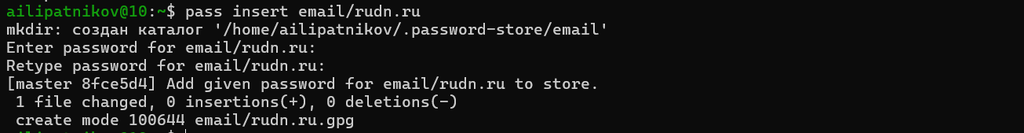

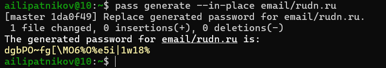

## Дополнительное ПО и шрифты

- Установлено ПО рабочего окружения: dunst, fuzzel, swaylock, kitty, waybar, wl-clipboard, mpv, grim, slurp
- Подключён репозиторий Copr с шрифтами iosevka
- Установлены варианты шрифта: fonts, aile, curly, slab, etoile, term

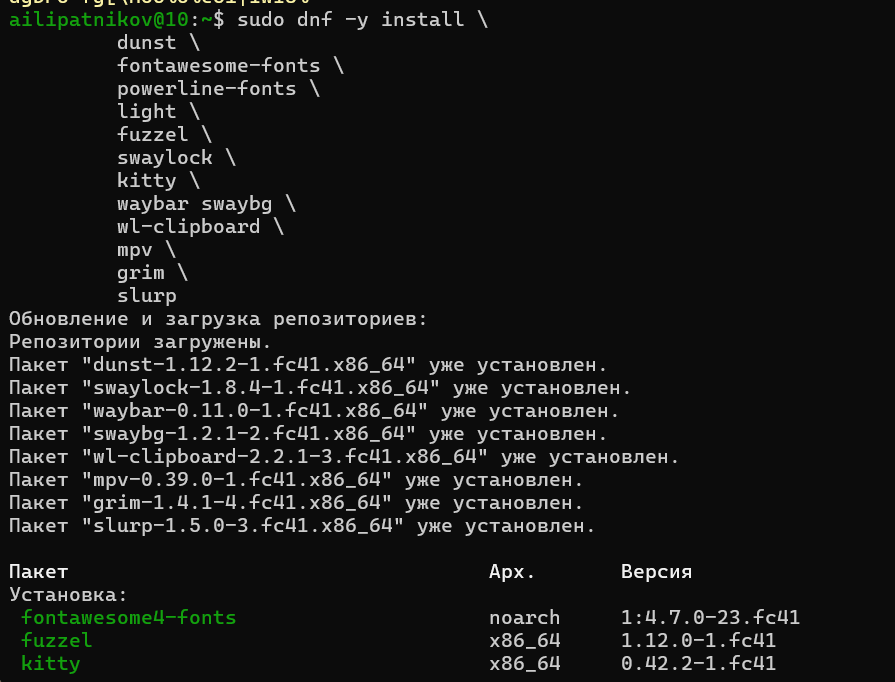

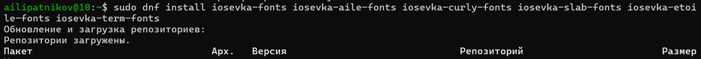

## Установка chezmoi и репозиторий dotfiles

- Бинарный файл chezmoi установлен скриптом, определяющим архитектуру системы:

```bash
sh -c "$(wget -qO- chezmoi.io/get)"
```

- Создан приватный репозиторий dotfiles из шаблона утилитой gh:

```bash
gh repo create dotfiles --template="yamadharma/dotfiles-template" --private
```

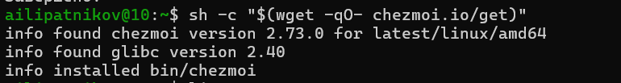

[figure not shown]

## Подключение репозитория к системе

- Инициализация: `chezmoi init git@github.com:pakarah/dotfiles.git`
- Проверка изменений до применения: `chezmoi diff`
- Применение с подробным выводом: `chezmoi apply -v`

## Вторая машина и настройка одной командой

- На второй машине: тот же цикл init, diff, apply — конфигурация воспроизводится
- Настройка новой машины одной командой:

```bash
chezmoi init --apply https://github.com/pakarah/dotfiles.git
```

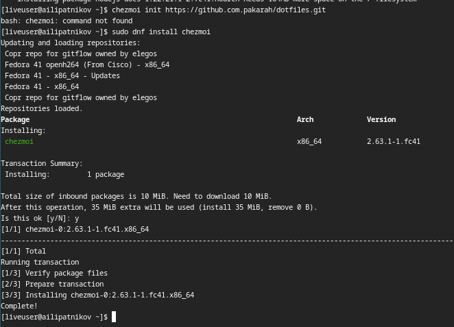

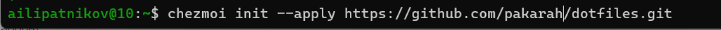

## Ежедневные операции

- Обновление одной командой: `chezmoi update`
  - эквивалент `git pull --autostash --rebase` и затем `chezmoi apply`
- Извлечение изменений без применения — с просмотром разницы:

```bash
chezmoi git pull -- --autostash --rebase && chezmoi diff
```

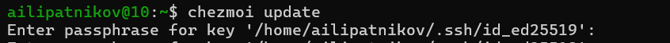

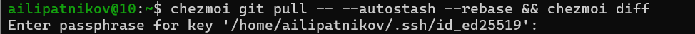

## Автоматическая фиксация изменений

- В конфигурацию добавлены опции автоматизации:

```
[git]
    autoCommit = true
    autoPush = true
```

- chezmoi фиксирует изменения исходного каталога и отправляет их в репозиторий
- Опции отключены по умолчанию и включаются явно

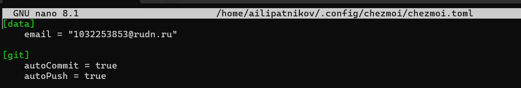

# Результаты

## Полученные результаты

- Настроено шифрованное хранилище паролей с синхронизацией через git и интеграцией с браузером

| Результат | Значение |
| --- | --- |
| Хранилище | `pass` + GPG-шифрование, репозиторий `pass.git` |
| Браузер | `browserpass` (native messaging) |
| Конфигурации | репозиторий `dotfiles` из шаблона, chezmoi |
| Развёртывание | `init`, `diff`, `apply`, `update` на двух машинах |

# Заключение

## Главный вывод

Освоен полный цикл управления личными данными и окружением: пароли хранятся шифрованно и синхронизируются через git, а файлы конфигурации разворачиваются на любой машине одной командой chezmoi — с предварительной проверкой изменений перед их применением.